# 6_Other_Regression_Types

MariaGladkaya

2023-12-18

# Dataset “blood.xlsx”

## Считываем дата-сет

```r
library(readxl)
blood <- read_excel("~/spbu_studies/mat_statistics/MatStat4-6/datasets/blood.xlsx")
View(blood)
```

## Ридж регрессия

### Постройте модель ридж регрессии для X1 как функции от X2 и X3. Используйте функции cv.plot и bias.plot для нахождения параметра k.

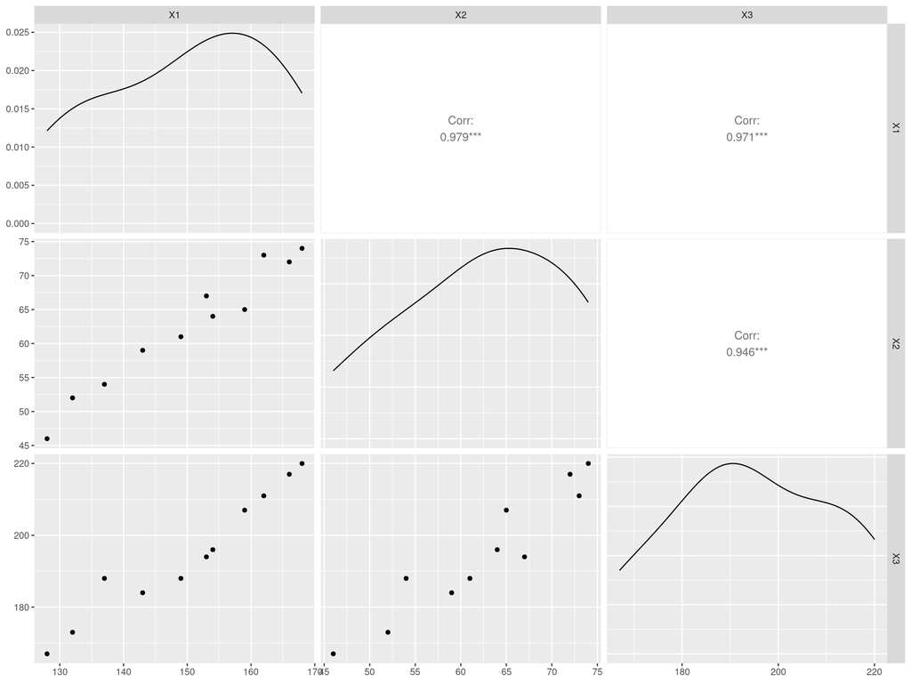

```r
library(MASS)
library(lmridge)
library(GGally)
library(ggplot2)
ggpairs(blood)
```

по графику видно, что у данных зависимость близка к линейной

```r
library(InformationValue)

df_fidgemod <- lmridge(blood$X1~., blood, lambda=0.05)
df_fidgemod
```

```
## Call:
## lmridge.default(formula = blood$X1 ~ ., data = blood, lambda = 0.05)
##
## Intercept        X2        X3
##  30.99410   0.86141   0.33486
```

Коэф-ты модели

#### изображаем хвосты в зависимости от лямбда

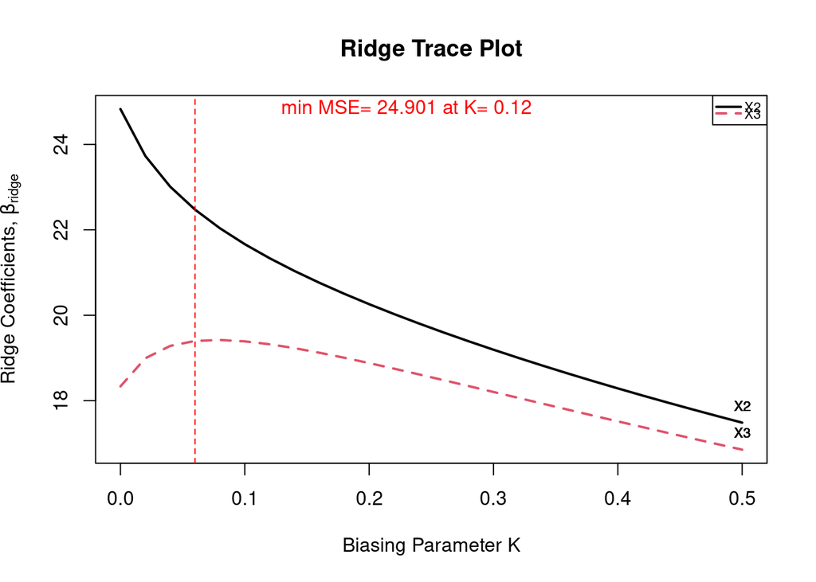

```r
blood_fidgemod <- lmridge(blood$X1~., data=blood, K=seq(0, 0.5, 0.02))
plot(blood_fidgemod, type = "ridge")
```

Как будет изменять оценка параметра в зависимости от параметра лямбда

В 0 совпадают с оценками метода наименьших квадратов

Минимум в ошибках при К=0,12

#### Проверьте мультиколлинеарность данных.

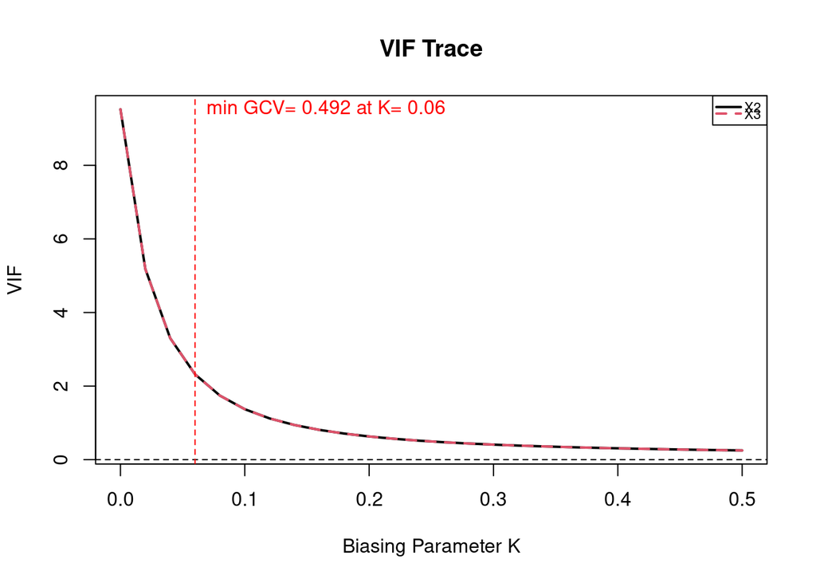

```r
plot(blood_fidgemod, type = "vif")
```

vif должен быть меньше 10. График показывает как vif меняется в зависимости от лямбда.

Мультиколлинеарность данных не выявлена при текущих значения К.

#### Смотрим как меняются коэф-ты AIC и BIC

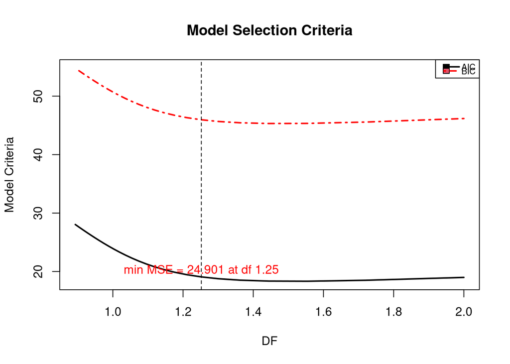

```r
info.plot(blood_fidgemod)
```

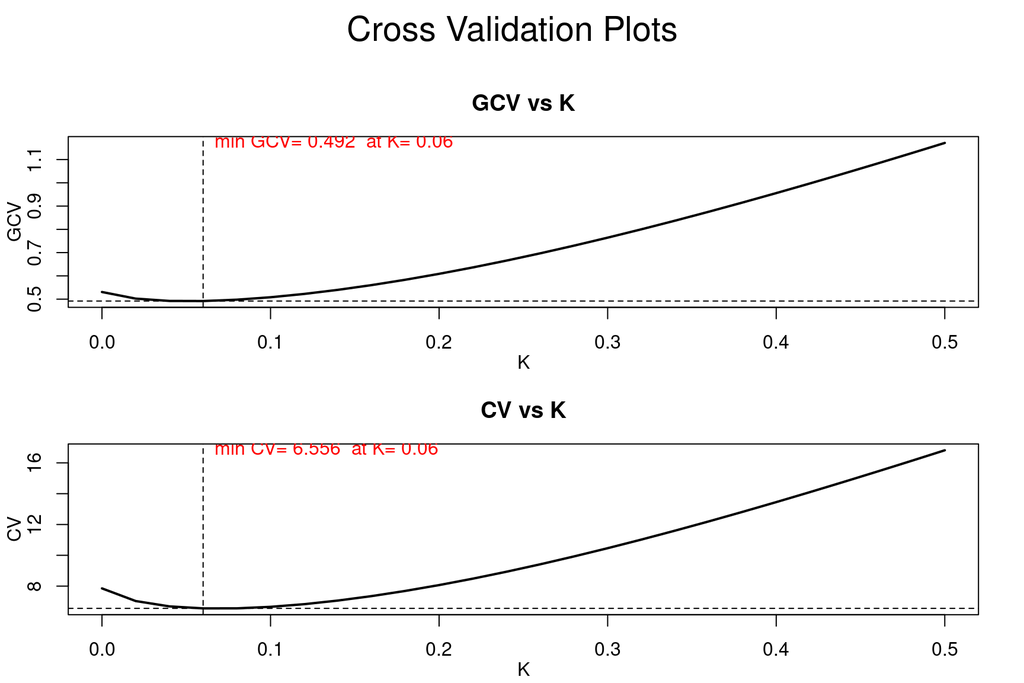

```r
cv.plot(blood_fidgemod)
```

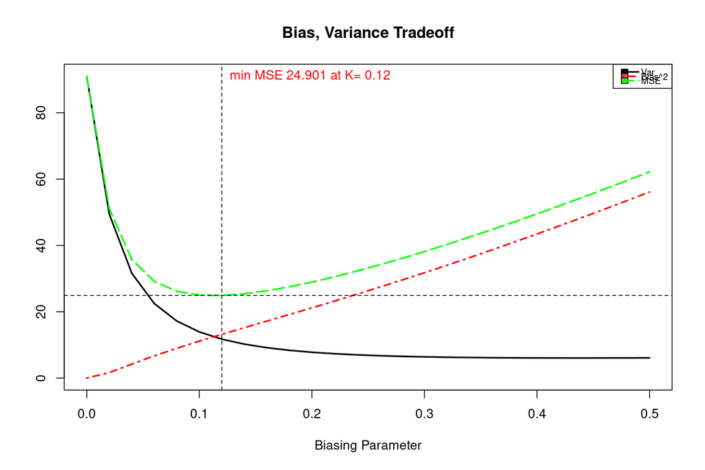

```r
bias.plot(blood_fidgemod)
```

#### Графики рекомендовали нам К=0,12 и К=0,06

```r
blood_fidgemod1 <- lmridge(blood$X1~., blood, K=0.12)
summary(blood_fidgemod1)
```

```
##
## Call:
## lmridge.default(formula = blood$X1 ~ ., data = blood, K = 0.12)
##
##
## Coefficients: for Ridge parameter K= 0.12
##             Estimate Estimate (Sc) StdErr (Sc) t-value (Sc)  Pr(>|t|)
## Intercept    35.0512    -4949.9722    495.8160      -9.9835 < 2.2e-16 ***
## X2            0.7402       21.3348      2.4214       8.8110 < 2.2e-16 ***
## X3            0.3529       19.3211      2.4214       7.9793 < 2.2e-16 ***
## ---
## Signif. codes:  0 '***' 0.001 '**' 0.01 '*' 0.05 '.' 0.1 ' ' 1
##
## Ridge Summary
##        R2    adj-R2  DF ridge         F       AIC       BIC
##   0.86620   0.85130   1.25205 173.16082  19.08211  45.95714
## Ridge minimum MSE= 24.901 at K= 0.12
## P-value for F-test ( 1.25205 , 9.479312 ) = 1.13674e-07
## -------------------------------------------------------------------
```

```r
blood_fidgemod2 <- lmridge(blood$X1~., blood, K=0.06)
summary(blood_fidgemod2)
```

```
##
## Call:
## lmridge.default(formula = blood$X1 ~ ., data = blood, K = 0.06)
##
##
## Coefficients: for Ridge parameter K= 0.06
##             Estimate Estimate (Sc) StdErr (Sc) t-value (Sc) Pr(>|t|)
## Intercept    32.3078    -5036.2312    686.2098      -7.3392    1e-04 ***
## X2            0.7797       22.4730      3.3513       6.7058    1e-04 ***
## X3            0.3543       19.3989      3.3513       5.7885    3e-04 ***
## ---
## Signif. codes:  0 '***' 0.001 '**' 0.01 '*' 0.05 '.' 0.1 ' ' 1
##
## Ridge Summary
##        R2    adj-R2  DF ridge         F       AIC       BIC
##   0.91880   0.90980   1.44352 187.29028  18.36631  45.31753
## Ridge minimum MSE= 29.14003 at K= 0.06
## P-value for F-test ( 1.44352 , 9.278175 ) = 6.995501e-08
## -------------------------------------------------------------------
```

Вторая модель лучше по AIC и предсказательной способности

```r
vif(blood_fidgemod2)
```

```
##             X2      X3
## k=0.06 2.31925 2.31925
```

Проблема мультиколлинеарности не обнаружена

### Проведите сравнительной анализ полученной модели с моделью линейной регрессии (когда оценки найдены по МНК).

#### Линейная модель

```r
blood_lin <- lm(blood$X1~., data=blood)
summary(blood_lin)
```

```
##
## Call:
## lm(formula = blood$X1 ~ ., data = blood)
##
## Residuals:
##     Min      1Q  Median      3Q     Max
## -3.4640 -1.1949 -0.4078  1.8511  2.6981
##
## Coefficients:
##             Estimate Std. Error t value Pr(>|t|)
## (Intercept)  30.9941    11.9438   2.595  0.03186 *
## X2            0.8614     0.2482   3.470  0.00844 **
## X3            0.3349     0.1307   2.563  0.03351 *
## ---
## Signif. codes:  0 '***' 0.001 '**' 0.01 '*' 0.05 '.' 0.1 ' ' 1
##
## Residual standard error: 2.318 on 8 degrees of freedom
## Multiple R-squared:  0.9768, Adjusted R-squared:  0.9711
## F-statistic: 168.8 on 2 and 8 DF,  p-value: 2.874e-07
```

Adjusted R-squared, R-squared увеличился в линейной модели

# Dataset “Kuiper.xls”

## Считываем дата-сет

```r
kuiper <- read_excel("~/spbu_studies/mat_statistics/MatStat4-6/datasets/kuiper_less.xls")
View(kuiper)
```

## Квантильная регрессия (Медианная)

Оценка метода наименьших модулей

На сколько отклоняется наблюдаемое значение от значения предсказанного по модели линейной регрессии

### Постройте квантильную регрессию для различных значений параметров «тау», Y = price – зависимая переменная, mileage, liter, cruise, sound, leather leather – независимые переменные).

```r
library(quantreg)
qreg1 <- rq(kuiper$Price~., tau=0.5, data = kuiper)
summary(qreg1)
```

```
##
## Call: rq(formula = kuiper$Price ~ ., tau = 0.5, data = kuiper)
##
## tau: [1] 0.5
##
## Coefficients:
##             coefficients lower bd    upper bd
## (Intercept)  6670.48365   5414.67440  8472.41054
## Mileage        -0.12289     -0.16614    -0.09624
## Liter        4383.62510   3561.08396  4721.63290
## Cruise       1360.78031   1022.04912  2674.79926
## Sound       -1760.28023  -2525.58686  -886.08973
## Leather      1055.59005    391.66341  1734.42700
```

Доверительные интервалы

```r
myqreg <- rq(kuiper$Price~., tau=1:9/10, data = kuiper)
```

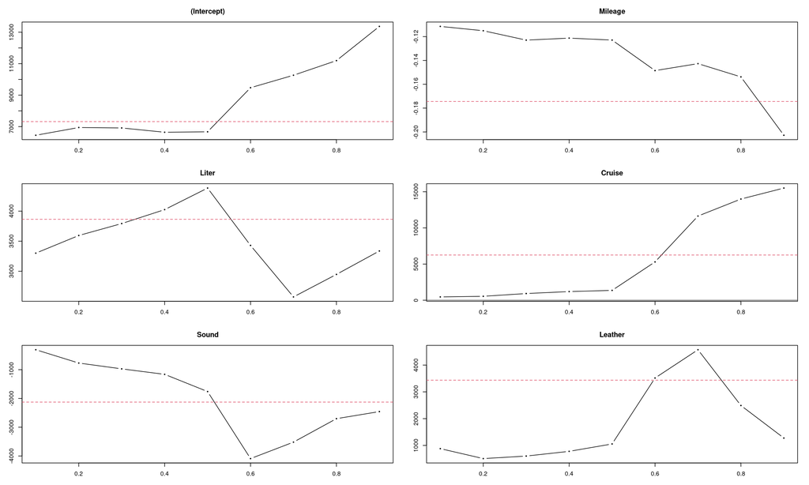

```r
plot(myqreg)
```

точки - значения коэф-та при соотв значении переменной

красная линия - сравнения с мотодом наим. квадратов

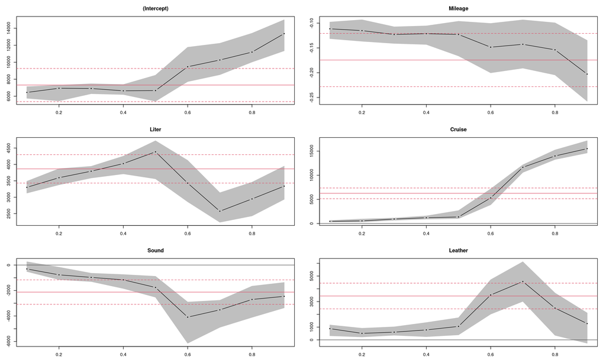

```r
plot(summary(myqreg))
```

Серая обл- доверительный интервал для коэф. квантильной регрессии

Красная обл- доверительный интервал для оценки методом наим. квадратов

#### Постороение линейной регрессии и сравнение с квантильной

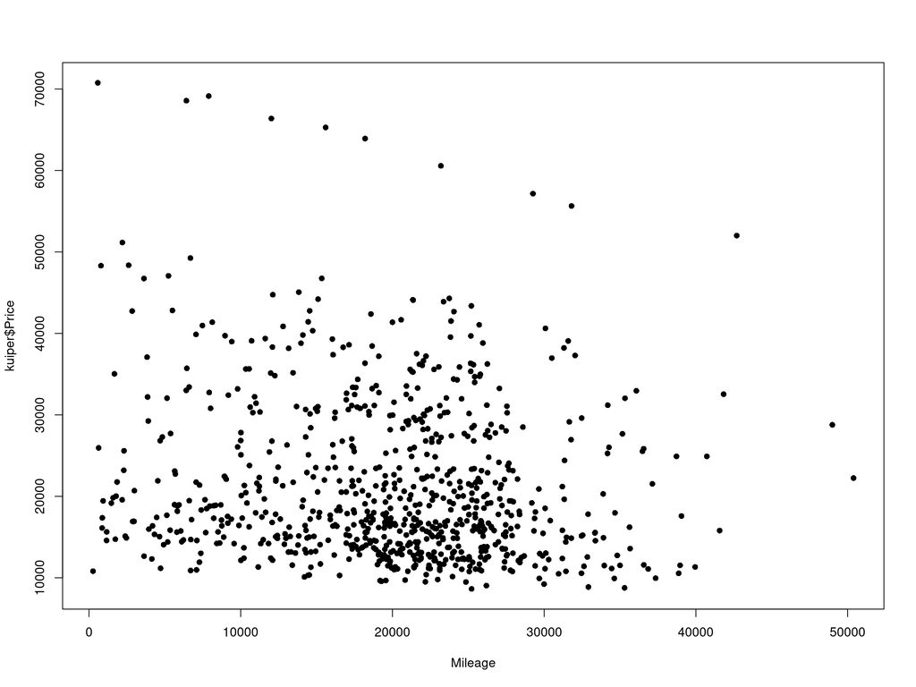

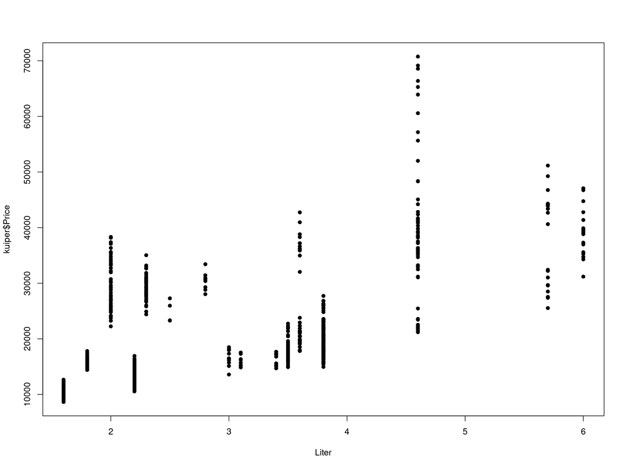

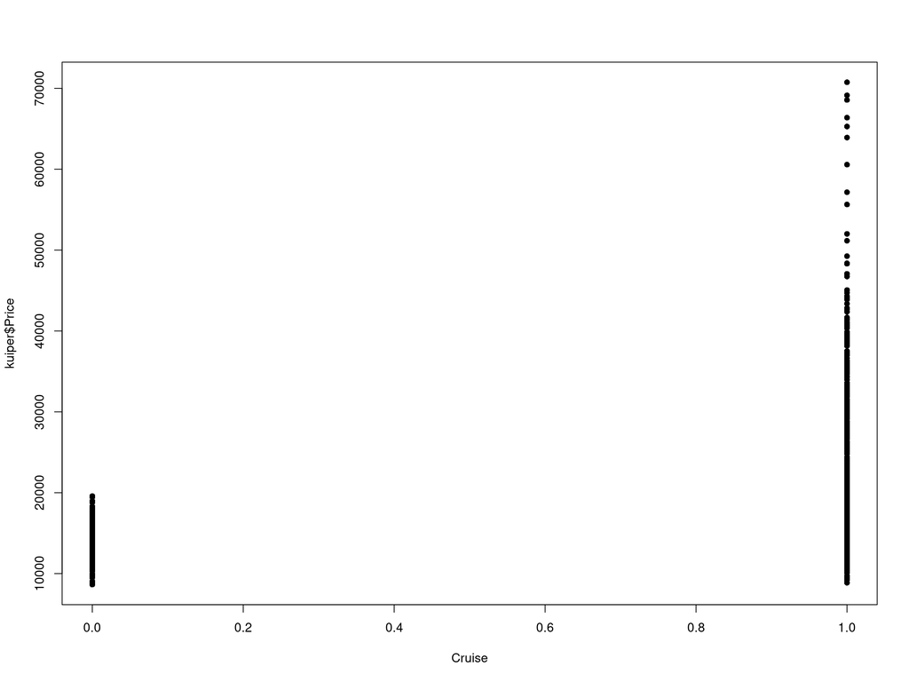

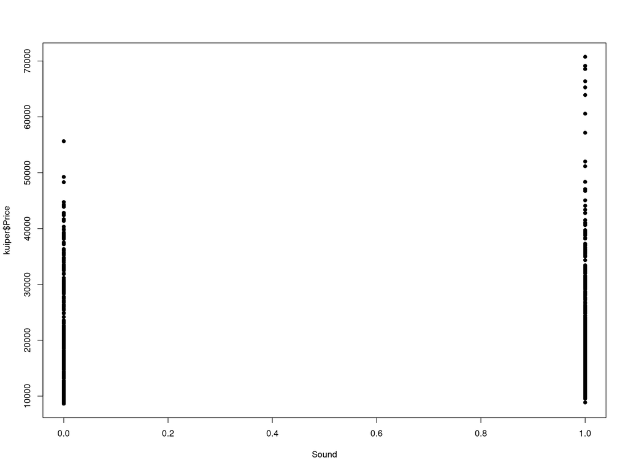

```r
kuiper_lin <- lm(kuiper$Price~., data=kuiper)
plot(kuiper$Price~., data = kuiper, pch=16)
```

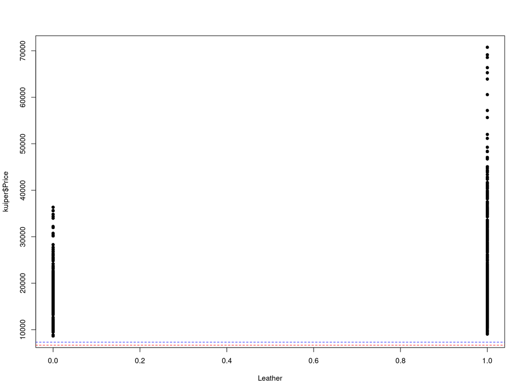

```r
abline(qreg1, col="red", lty=2)
abline(kuiper_lin, col="blue", lty=2)
```

Медианная регрессия более устойчива к выбросам, те выбросы не сильно меняют угол наклона

```r
summary(kuiper_lin)
```

```
##
## Call:
## lm(formula = kuiper$Price ~ ., data = kuiper)
##
## Residuals:
##    Min     1Q Median     3Q    Max
## -12328  -5660  -1700   4546  38203
##
## Coefficients:
##               Estimate Std. Error t value Pr(>|t|)
## (Intercept)  7.318e+03  1.184e+03   6.182 1.01e-09 ***
## Mileage     -1.744e-01  3.265e-02  -5.342 1.20e-07 ***
## Liter        3.864e+03  2.636e+02  14.658  < 2e-16 ***
## Cruise       6.251e+03  6.741e+02   9.273  < 2e-16 ***
## Sound       -2.126e+03  5.832e+02  -3.646 0.000284 ***
## Leather      3.436e+03  6.121e+02   5.613 2.74e-08 ***
## ---
## Signif. codes:  0 '***' 0.001 '**' 0.01 '*' 0.05 '.' 0.1 ' ' 1
##
## Residual standard error: 7574 on 798 degrees of freedom
## Multiple R-squared:  0.4165, Adjusted R-squared:  0.4129
## F-statistic: 113.9 on 5 and 798 DF,  p-value: < 2.2e-16
```

# Dataset “cigarettes.txt”

## Считываем дата-сет

```r
cigar <- read_excel("~/spbu_studies/mat_statistics/MatStat4-6/datasets/cigarettes.xlsx")
View(cigar)
```

## Нелинейная регрессия

### Квадратичная модель

```r
quadratic <- lm(cigar$y~. + I(cigar$x1^2) + I(cigar$x2 ^2)+ I(cigar$x3 ^2), data = cigar)
summary(quadratic)
```

```
##
## Call:
## lm(formula = cigar$y ~ . + I(cigar$x1^2) + I(cigar$x2^2) + I(cigar$x3^2),
##     data = cigar)
##
## Residuals:
##     Min      1Q  Median      3Q     Max
## -1.1718 -0.4572 -0.0429  0.4489  1.9682
##
## Coefficients:
##                Estimate Std. Error t value Pr(>|t|)
## (Intercept)    32.69795   24.12424   1.355   0.1921
## x1              4.08769    5.88403   0.695   0.4961
## x2            -70.95089   50.39281  -1.408   0.1762
## x3              0.97635    0.44948   2.172   0.0434 *
## I(cigar$x1^2)   2.83008    2.24491   1.261   0.2235
## I(cigar$x2^2)  35.33159   25.49353   1.386   0.1827
## I(cigar$x3^2)  -0.02007    0.01348  -1.489   0.1539
## ---
## Signif. codes:  0 '***' 0.001 '**' 0.01 '*' 0.05 '.' 0.1 ' ' 1
##
## Residual standard error: 0.9348 on 18 degrees of freedom
## Multiple R-squared:  0.9796, Adjusted R-squared:  0.9728
## F-statistic:   144 on 6 and 18 DF,  p-value: 3.264e-14
```

### Кубическая модель

```r
cubic <- lm(cigar$y~ poly(cigar$x1, degree=3)+ poly(cigar$x2, degree=3) + poly(cigar$x3, degree=3), data = cigar)
summary(cubic)
```

```
##
## Call:
## lm(formula = cigar$y ~ poly(cigar$x1, degree = 3) + poly(cigar$x2,
##     degree = 3) + poly(cigar$x3, degree = 3), data = cigar)
##
## Residuals:
##      Min       1Q   Median       3Q      Max
## -1.31653 -0.39650 -0.01898  0.25659  1.59131
##
## Coefficients:
##                             Estimate Std. Error t value Pr(>|t|)
## (Intercept)                  12.2160     0.1717  71.156  < 2e-16 ***
## poly(cigar$x1, degree = 3)1  21.4951     4.1823   5.139 0.000121 ***
## poly(cigar$x1, degree = 3)2  -0.7982     3.6065  -0.221 0.827817
## poly(cigar$x1, degree = 3)3   4.4032     3.2708   1.346 0.198226
## poly(cigar$x2, degree = 3)1   0.6044     1.6601   0.364 0.720890
## poly(cigar$x2, degree = 3)2   0.4804     1.3740   0.350 0.731444
## poly(cigar$x2, degree = 3)3   1.1340     1.6263   0.697 0.496315
## poly(cigar$x3, degree = 3)1   6.0706     3.9760   1.527 0.147615
## poly(cigar$x3, degree = 3)2   1.6114     3.6162   0.446 0.662244
## poly(cigar$x3, degree = 3)3  -5.8522     2.6972  -2.170 0.046503 *
## ---
## Signif. codes:  0 '***' 0.001 '**' 0.01 '*' 0.05 '.' 0.1 ' ' 1
##
## Residual standard error: 0.8584 on 15 degrees of freedom
## Multiple R-squared:  0.9857, Adjusted R-squared:  0.977
## F-statistic: 114.5 on 9 and 15 DF,  p-value: 3.503e-12
```

Уравнения записываюся с коэф-тами при соответствующей степени

### Линейная модель

```r
cigar_lin <- lm(cigar$y~., data=cigar)
summary(cigar_lin)
```

```
##
## Call:
## lm(formula = cigar$y ~ ., data = cigar)
##
## Residuals:
##      Min       1Q   Median       3Q      Max
## -1.78825 -0.60872 -0.06484  0.53241  2.17321
##
## Coefficients:
##             Estimate Std. Error t value Pr(>|t|)
## (Intercept)  -1.9348     2.3185  -0.835 0.413380
## x1           12.1577     1.0676  11.388  1.9e-10 ***
## x2           -0.1647     2.6198  -0.063 0.950459
## x3            0.2829     0.0696   4.064 0.000557 ***
## ---
## Signif. codes:  0 '***' 0.001 '**' 0.01 '*' 0.05 '.' 0.1 ' ' 1
##
## Residual standard error: 0.9743 on 21 degrees of freedom
## Multiple R-squared:  0.9741, Adjusted R-squared:  0.9704
## F-statistic: 263.5 on 3 and 21 DF,  p-value: < 2.2e-16
```